# Økonomisk overblik: Maja og Marni Niclasen

Dette dokument giver et overblik over både vores virksomhed Niclasen Housing og vores privatøkonomi. Vi starter med introduktion af vores virksomhed og forretningsmodel. Dernæst giver vi et overblik over vores samlede økonomi og udvikling over tid. Efterfølgende kommer der en række tabeller, som giver et mere detaljeret overblik over vores virksomheds økonomi.

## Niclasen Housing

Vores virksomhed er specialiseret i at give udvekslingsstuderende ved Arhus Universitet et godt og sikkert sted at bo mens de opholder sig Danmark. De studerende er typisk 6 til 12 måneder i Danmark (1 til 2 semstre). Henover sommeren har vi også et hold til summer school.

Vi har 4 parcelhuse omrking Ringvejen i Aarhus, som er udlejet til Aarhus universitet på attraktive vilkår, som gør at vi ikke har nogen tomgangsrisiko. Dette kom os for eksempel til gode under corona, hvor husene ikke var fulde af studerende, men vi stadig fik en fuld husleje.

Som udlejer, er det vigtigt for os at de studerende har gode forhold og trives undder deres korte ophold i Aarhus. Vi sørger derfor altid for, at værelser og fællesarealer er velholdte. Vi har også løbende kontakt med de studerende og hjælper dem med råd og vejledning, punkterede cykler, opbevaring af bagage og meget andet. Vi arrangerer også båd- og gåture for at hjælpe de sociale relationer påvej. Vi har over de seneste år også lavet spørgeskemaundersøgelser for at bedre forstå hvad vi kan gøre for at deres ophold bliver så godt som muligt.

Alt dette gør vi fordi, vi godt kan lide det og synes at det er det rigtige - men vi gør det også for at vi har en glad lejer i Aarhus Universitet, som skal bruge minimal ressourcer på vores lejere sammenlignet med udvekslingstuderende der bor andre steder. Vi forventer derfor at have et samarbejde med Aarhus Universitet mange år frem.

## Overblik over Niclasen Housing og samlet formue

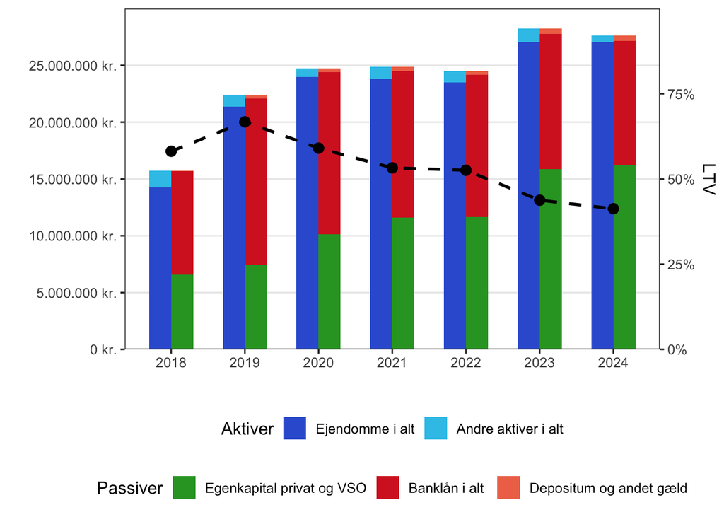

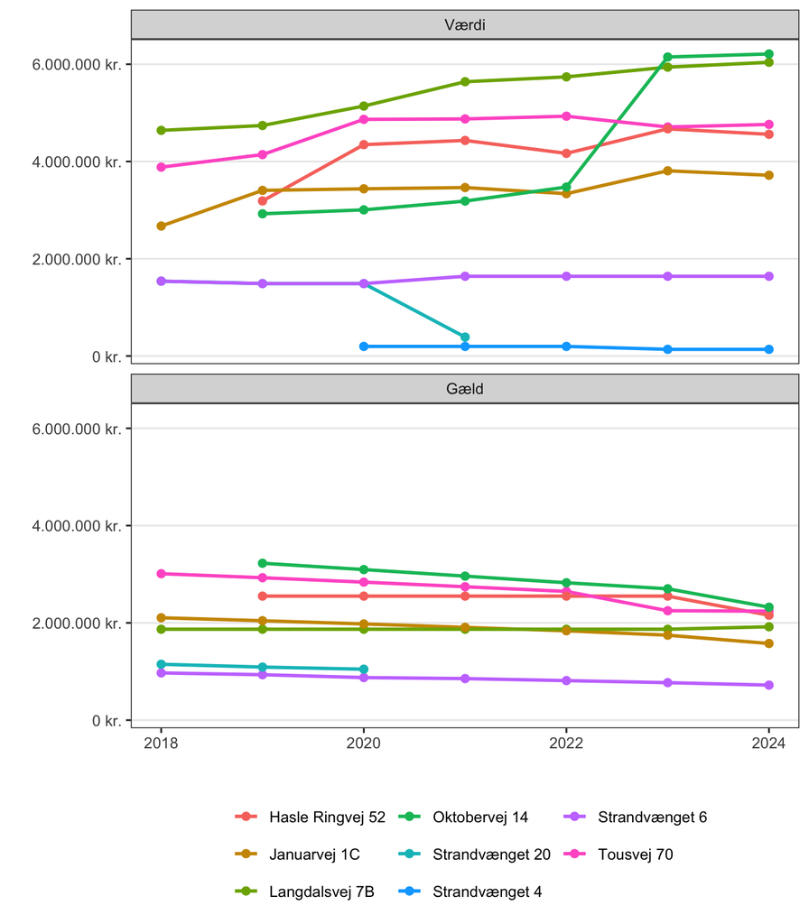

### Niclasen Housing

Vi købte de første to huse i 2018 og de to næste i 2019. I takt med at vi fik dem sat i stand er husene blevet udlejet. Tidslinjen er kort ridset op her:

- **2019:** Tousvej udlejet i Februar og Januarvej udlejet i september.
- **2020:** Hasle Ringvej udlejet juni. Oktobervej også delvist udlejet før det blev isandsat.
- **2023:** Oktobervej bliver færdig og udlejet i Februar. Samme år nedlægger vi et værelser på Tousvej for at skabe bedre fællesarealer for de studerende.

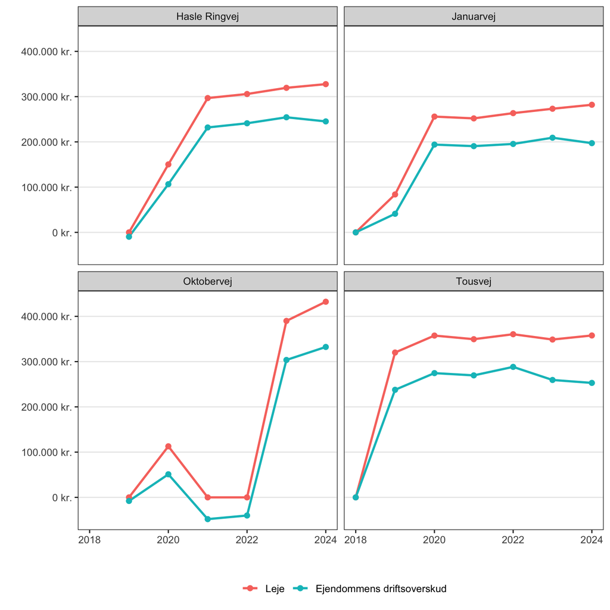

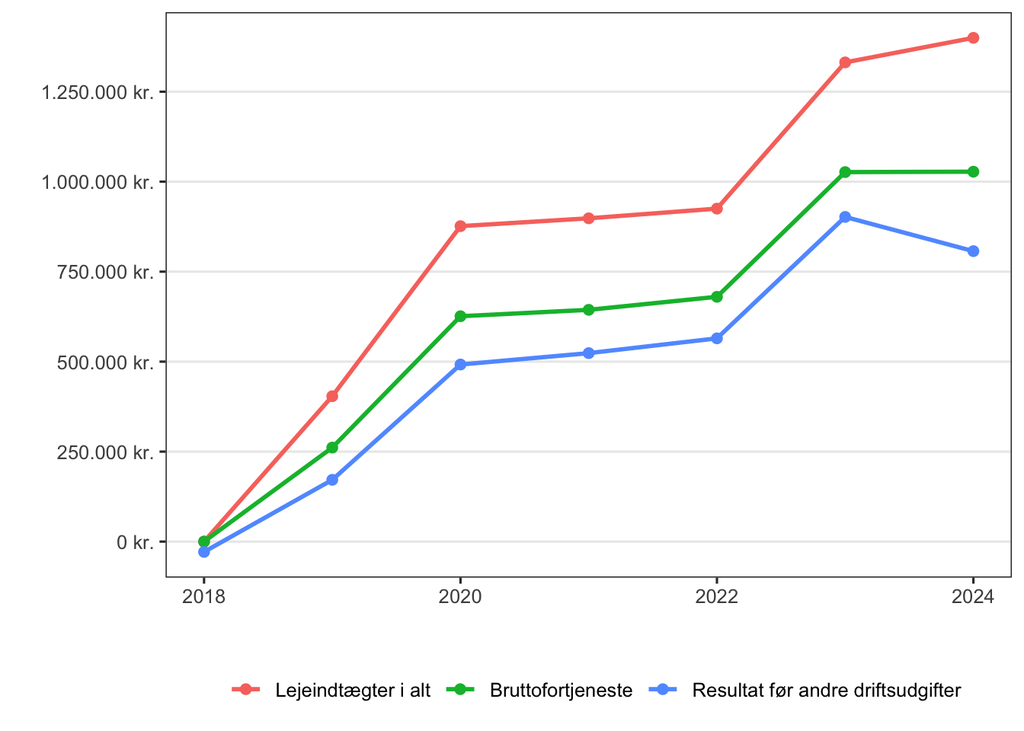

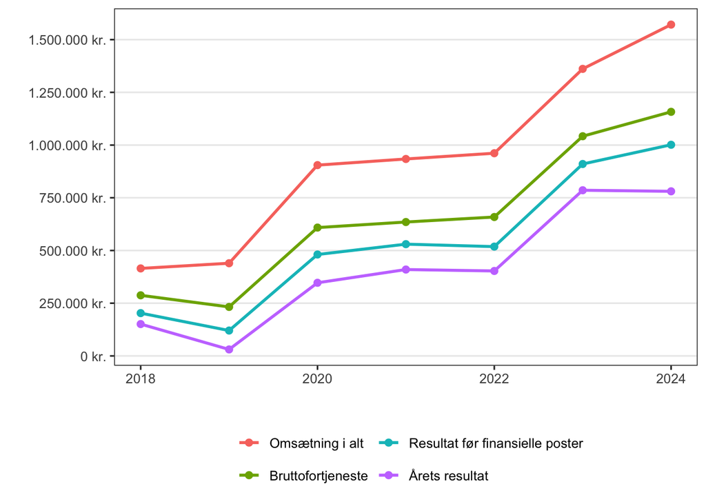

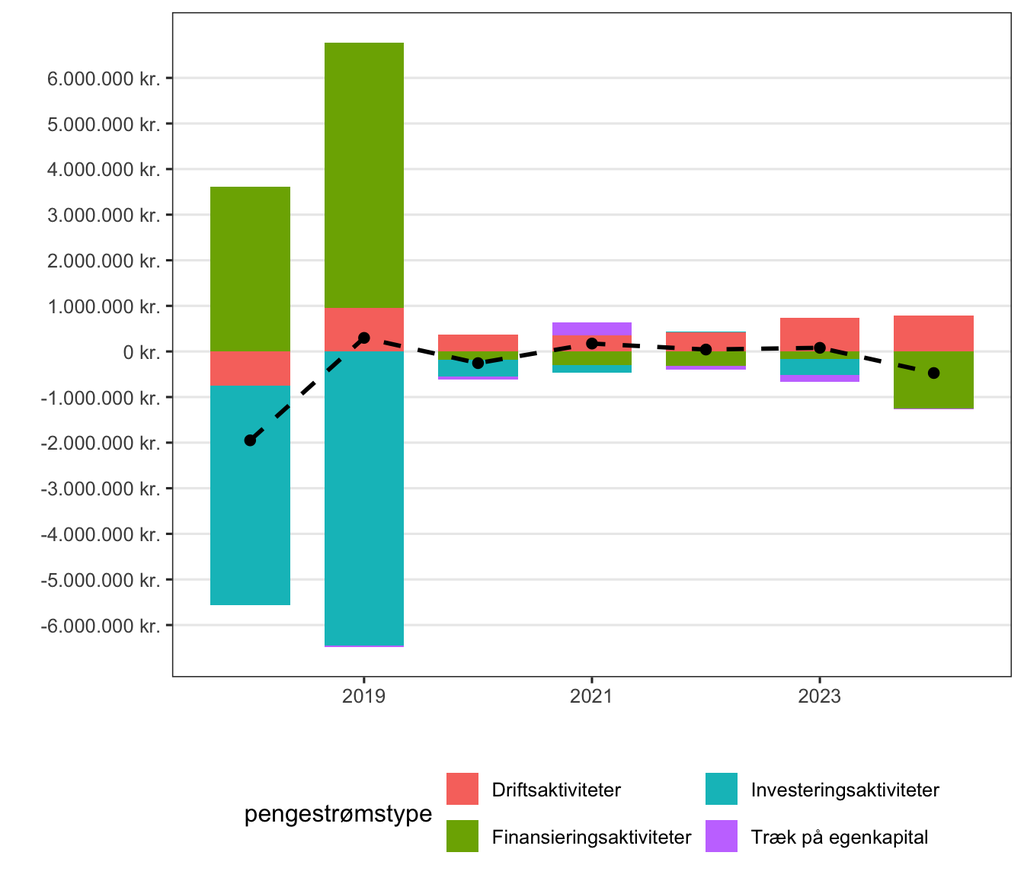

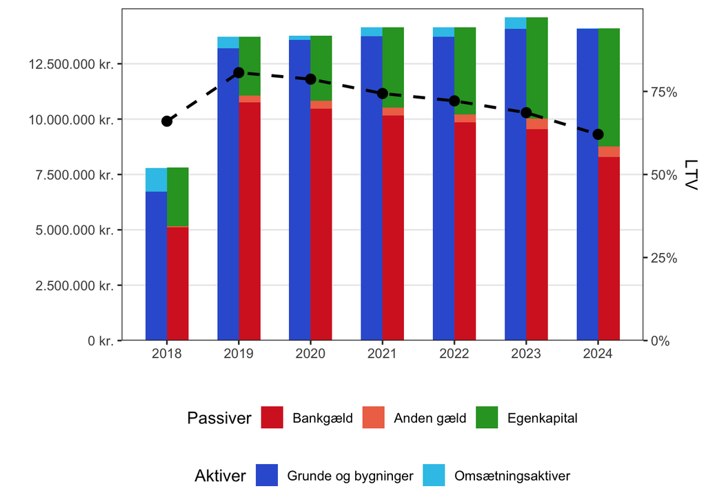

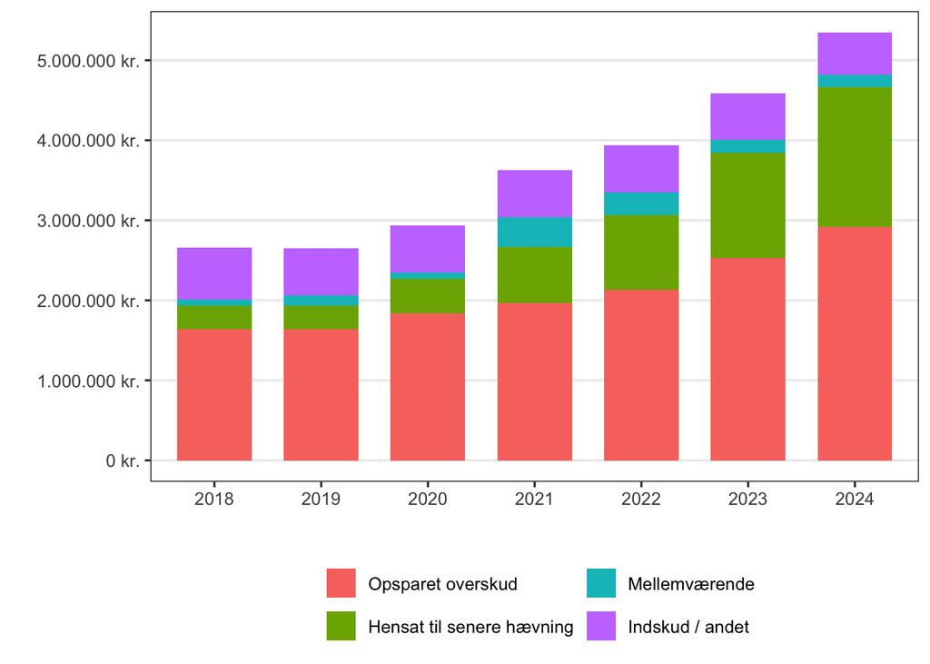

### Formue overblik

| text | 2018 | 2019 | 2020 | 2021 | 2022 | 2023 | 2024 |
| --- | --- | --- | --- | --- | --- | --- | --- |
| Langdalsvej 7B | 4.640.000 | 4.740.000 | 5.140.000 | 5.640.000 | 5.740.000 | 5.940.000 | 6.040.000 |
| Strandvænget 20 | 1.540.000 | 1.490.000 | 1.490.000 | 390.000 | 0 | 0 | 0 |
| Strandvænget 6 | 1.540.000 | 1.490.000 | 1.490.000 | 1.640.000 | 1.640.000 | 1.640.000 | 1.640.000 |
| Strandvænget 4 | 0 | 0 | 198.000 | 198.000 | 198.000 | 138.000 | 138.000 |
| Januarvej 1C | 2.673.000 | 3.406.200 | 3.438.400 | 3.464.280 | 3.338.100 | 3.808.869 | 3.717.000 |
| Tousvej 70 | 3.884.000 | 4.141.720 | 4.866.560 | 4.875.100 | 4.931.380 | 4.709.569 | 4.762.000 |
| Hasle Ringvej 52 | 0 | 3.189.000 | 4.346.820 | 4.432.840 | 4.166.980 | 4.671.441 | 4.559.000 |
| Oktobervej 14 | 0 | 2.925.000 | 3.006.000 | 3.186.000 | 3.475.000 | 6.148.385 | 6.211.000 |
| Ejendomme i alt | 14.277.000 | 21.381.920 | 23.975.780 | 23.826.220 | 23.489.460 | 27.056.264 | 27.067.000 |
| Andre private aktiver | 113.000 | 129.000 | 120.000 | 112.000 | 109.000 | 102.000 | 100.000 |
| Likvide beholdninger, privat | 106.000 | 164.000 | 233.000 | 284.000 | 227.000 | 246.000 | 91.000 |
| Pension, tidlig udtrækning | 193.000 | 217.000 | 243.000 | 251.000 | 278.000 | 306.000 | 326.000 |
| Likvider og tilgodehavende, VSO | 1.061.000 | 505.000 | 186.000 | 393.000 | 409.000 | 515.000 | 20.000 |
| Andre aktiver i alt | 1.473.000 | 1.015.000 | 782.000 | 1.040.000 | 1.023.000 | 1.169.000 | 537.000 |
| Aktiver privat og VSO | 15.750.000 | 22.396.920 | 24.757.780 | 24.866.220 | 24.512.460 | 28.225.264 | 27.604.000 |
| Lån Langdalsvej 7B | 1.869.000 | 1.869.000 | 1.869.000 | 1.869.000 | 1.869.000 | 1.869.000 | 1.920.000 |
| Lån Strandvænget 6 | 971.000 | 934.000 | 875.000 | 854.000 | 813.000 | 771.000 | 720.000 |
| Lån Strandvænget 20 | 1.149.000 | 1.091.000 | 1.047.000 | 0 | 0 | 0 | 0 |
| Lån Januarvej 1C | 2.105.000 | 2.044.000 | 1.978.000 | 1.908.000 | 1.837.000 | 1.747.000 | 1.576.000 |
| Lån Tousvej 70 | 3.011.000 | 2.928.000 | 2.838.000 | 2.743.000 | 2.647.000 | 2.250.000 | 2.240.000 |
| Lån Hasle Ringvej 52 | 0 | 2.550.000 | 2.550.000 | 2.550.000 | 2.550.000 | 2.550.000 | 2.157.000 |
| Lån Oktobervej 14 | 0 | 3.226.000 | 3.096.000 | 2.961.000 | 2.825.000 | 2.701.000 | 2.323.000 |
| Banklån i alt | 9.105.000 | 14.642.000 | 14.253.000 | 12.885.000 | 12.541.000 | 11.888.000 | 10.936.000 |
| Depositum og andet gæld | 49.000 | 312.000 | 364.000 | 359.000 | 344.000 | 465.000 | 456.000 |
| Egenkapital privat og VSO | 6.596.000 | 7.442.920 | 10.140.780 | 11.622.220 | 11.627.460 | 15.872.264 | 16.212.000 |
| Passiver privat og VSO | 15.750.000 | 22.396.920 | 24.757.780 | 24.866.220 | 24.512.460 | 28.225.264 | 27.604.000 |

### Resultat af virksomhedsdriften

#### Resultatopgørelse

| group_level_2 | 2018 | 2019 | 2020 | 2021 | 2022 | 2023 | 2024 |
| --- | --- | --- | --- | --- | --- | --- | --- |
| Udlejning | 0 | 403.906 | 876.452 | 898.223 | 925.118 | 1.331.386 | 1.399.624 |
| Håndværksarbejde | 45.786 | 35.697 | 28.446 | 35.816 | 36.178 | 29.943 | 171.619 |
| Fortjeneste ved salg | 369.211 | 0 | 0 | 0 | 0 | 0 | 0 |
| Omsætning i alt | 414.997 | 439.603 | 904.898 | 934.039 | 961.297 | 1.361.329 | 1.571.243 |
| Ejendomsdrift | (63.390) | (150.666) | (250.347) | (254.281) | (244.989) | (304.799) | (371.890) |
| Vareforbrug | (64.153) | (56.522) | (45.872) | (44.745) | (57.498) | (14.629) | (41.753) |
| Direkte driftsudgifter i alt | (127.543) | (207.188) | (296.219) | (299.027) | (302.487) | (319.428) | (413.643) |
| Bruttofortjeneste | 287.454 | 232.415 | 608.679 | 635.012 | 658.810 | 1.041.900 | 1.157.600 |
| Repræsentation/Marketing | (2.433) | (1.118) | (803) | (1.880) | (4.161) | (8.140) | (7.010) |
| Autodrift | (23.531) | (26.870) | (68.919) | (67.288) | (92.888) | (79.322) | (85.613) |
| Personale omkostninger | (7.860) | (14.611) | (6.052) | (1.234) | (2.608) | (9.239) | (11.542) |
| Administration | (50.622) | (69.444) | (51.917) | (34.538) | (40.762) | (34.993) | (52.040) |
| Andre driftsudgifter i alt | (84.446) | (112.042) | (127.691) | (104.940) | (140.418) | (131.693) | (156.205) |
| Resultat før finansielle poster | 203.008 | 120.373 | 480.987 | 530.072 | 518.391 | 910.207 | 1.001.395 |
| Renteomkostninger | (45.465) | (80.617) | (129.946) | (116.292) | (111.402) | (120.860) | (169.815) |
| Gebyr | (6.482) | (8.991) | (4.181) | (4.044) | (4.055) | (3.661) | (50.907) |
| Finansielle poster i alt | (51.947) | (89.608) | (134.127) | (120.337) | (115.457) | (124.521) | (220.722) |
| Årets resultat | 151.061 | 30.765 | 346.860 | 409.735 | 402.934 | 785.687 | 780.673 |

#### Fokus på AU huse

| group_level_3 | 2018 | 2019 | 2020 | 2021 | 2022 | 2023 | 2024 |
| --- | --- | --- | --- | --- | --- | --- | --- |
| Tousvej: Leje | 0 | 320.086 | 357.532 | 349.543 | 360.514 | 348.811 | 357.760 |
| Januarvej: Leje | 0 | 83.820 | 255.864 | 251.884 | 263.491 | 273.198 | 281.984 |
| Hasle Ringvej: Leje | 0 | 0 | 150.196 | 296.796 | 305.762 | 319.416 | 327.582 |
| Oktobervej: Leje | 0 | 0 | 112.860 | 0 | 0 | 389.961 | 432.300 |
| Alle huse: Korrektion | 0 | 0 | 0 | 0 | (4.648) | (0) | 0 |
| Lejeindtægter i alt | 0 | 403.906 | 876.452 | 898.223 | 925.118 | 1.331.386 | 1.399.624 |
| Varme | 0 | (22.925) | (52.439) | (47.190) | (48.416) | (51.952) | (79.331) |
| Vand | 0 | (17.965) | (46.085) | (38.542) | (30.832) | (56.921) | (68.004) |
| EL | 0 | (16.660) | (27.466) | (33.830) | (49.836) | (34.888) | (48.841) |
| Affald | 0 | (5.852) | (10.272) | (12.139) | (12.880) | (13.900) | (19.489) |
| Ejendomsskat | 0 | (36.232) | (66.188) | (66.204) | (65.852) | (65.863) | (45.211) |
| Husforsikring | 0 | (26.453) | (26.668) | (27.539) | (25.362) | (25.877) | (29.990) |
| Vedligehold | 0 | (16.598) | (21.228) | (28.837) | (11.811) | (55.398) | (81.025) |
| Driftsudgifter i alt | 0 | (142.686) | (250.347) | (254.281) | (244.989) | (304.799) | (371.890) |
| Bruttofortjeneste | 0 | 261.220 | 626.105 | 643.942 | 680.129 | 1.026.586 | 1.027.734 |
| Renteomkostninger | (22.184) | (80.617) | (129.946) | (116.292) | (111.402) | (120.860) | (169.815) |
| Gebyr | (6.482) | (8.991) | (4.181) | (4.044) | (4.055) | (3.661) | (50.907) |
| Finansielle poster i alt | (28.666) | (89.608) | (134.127) | (120.337) | (115.457) | (124.521) | (220.722) |
| Resultat før andre driftsudgifter | (28.666) | 171.612 | 491.978 | 523.605 | 564.672 | 902.065 | 807.012 |

### Balancen

#### Aktiver

| group_level_2 | 2018 | 2019 | 2020 | 2021 | 2022 | 2023 | 2024 |
| --- | --- | --- | --- | --- | --- | --- | --- |
| Grunde og bygninger: Tousvej | 3.994.832 | 4.118.964 | 4.138.208 | 4.138.208 | 4.138.208 | 4.290.187 | 4.290.187 |
| Grunde og bygninger: Januarvej | 2.736.934 | 2.877.562 | 2.888.078 | 2.888.078 | 2.577.916 | 2.581.665 | 2.581.665 |
| Grunde og bygninger: Oktobervej | 0 | 2.972.120 | 3.053.249 | 3.232.898 | 3.521.610 | 3.693.143 | 3.693.143 |
| Grunde og bygninger: Hasle Ringvej | 0 | 3.239.021 | 3.492.371 | 3.492.371 | 3.492.371 | 3.515.876 | 3.515.876 |
| Grunde og bygninger i alt | 6.731.766 | 13.207.668 | 13.571.907 | 13.751.555 | 13.730.105 | 14.080.870 | 14.080.870 |
| Varebeholdning | 15.050 | 15.050 | 15.050 | 15.050 | 15.050 | 15.050 | 15.050 |
| Tilgodhavender | 906.980 | 44.621 | (0) | 34.179 | 7.934 | 34.441 | 12.310 |
| Tilgodhavender | 10.074 | 19.236 | 0 | 0 | 0 | 0 | 0 |
| Andre tilgodehavender | 0 | 0 | 0 | 0 | 0 | 0 | 0 |
| Likvide beholdninger | 129.036 | 426.547 | 170.654 | 344.033 | 386.024 | 465.822 | (7.419) |
| Omsætningsaktiver i alt | 1.061.140 | 505.453 | 185.704 | 393.261 | 409.008 | 515.313 | 19.941 |
| Aktiver i alt | 7.792.906 | 13.713.121 | 13.757.610 | 14.144.817 | 14.139.113 | 14.596.183 | 14.100.811 |

#### Passiver

| group_level_2 | 2018 | 2019 | 2020 | 2021 | 2022 | 2023 | 2024 |
| --- | --- | --- | --- | --- | --- | --- | --- |
| Bankgæld: Januarvej | 2.105.070 | 2.043.564 | 1.977.690 | 1.907.668 | 1.836.927 | 1.746.854 | 1.576.474 |
| Bankgæld: Tousvej | 3.011.121 | 2.927.904 | 2.838.491 | 2.743.185 | 2.646.900 | 2.549.554 | 2.240.253 |
| Bankgæld: Hasle Ringvej | 0 | 2.550.000 | 2.550.000 | 2.550.000 | 2.550.000 | 2.550.000 | 2.157.281 |
| Bankgæld: Oktobervej | 0 | 3.226.413 | 3.095.578 | 2.960.906 | 2.824.607 | 2.701.244 | 2.323.225 |
| Bankgæld i alt | 5.116.192 | 10.747.882 | 10.461.759 | 10.161.760 | 9.858.434 | 9.547.652 | 8.297.233 |
| Depositum | 0 | 149.865 | 223.245 | 223.245 | 223.245 | 326.103 | 326.103 |
| Kreditorer | 44.984 | 109.914 | 50.682 | 35.663 | 27.176 | 9.098 | 0 |
| Skyldig moms | (11.962) | (13.673) | 33 | 0 | 0 | 0 | (2.079) |
| Revisor | 16.000 | 16.000 | 16.000 | 16.000 | 16.000 | 16.000 | 16.000 |
| Foudbetalt leje | 0 | 49.955 | 74.415 | 83.989 | 77.506 | 114.092 | 115.842 |
| Anden gæld i alt | 49.022 | 312.061 | 364.375 | 358.897 | 343.927 | 465.293 | 455.866 |
| Mellemværende | 75.000 | 135.000 | 76.996 | 370.421 | 293.398 | 166.112 | 162.626 |
| Hensat til senere hævning | 293.091 | 288.745 | 432.629 | 700.997 | 933.008 | 1.314.621 | 1.737.742 |
| Opsparet overskud | 1.640.459 | 1.641.711 | 1.834.732 | 1.967.034 | 2.127.757 | 2.525.616 | 2.921.763 |
| Indskud / andet | 648.893 | 587.724 | 587.120 | 585.710 | 582.589 | 576.899 | 525.581 |
| Egenkapital | 2.657.443 | 2.653.180 | 2.931.477 | 3.624.162 | 3.936.752 | 4.583.248 | 5.347.712 |
| Passiver i alt | 7.822.656 | 13.713.123 | 13.757.611 | 14.144.818 | 14.139.113 | 14.596.192 | 14.100.811 |

### Pengestrømme

| text | 2018 | 2019 | 2020 | 2021 | 2022 | 2023 | 2024 |
| --- | --- | --- | --- | --- | --- | --- | --- |
| Årets resultat | 151.061 | 30.765 | 346.860 | 409.735 | 402.934 | 785.687 | 780.673 |
| Ændring i tilgodehavende | (893.992) | 853.197 | 63.856 | (34.179) | 26.245 | (26.507) | 22.131 |
| Ændring i skyldig beløb | (12.016) | 63.220 | (45.526) | (15.052) | (8.487) | (18.078) | (11.177) |
| Pengestrøm fra drift | (754.948) | 947.182 | 365.190 | 360.505 | 420.692 | 741.102 | 791.627 |
| Ej fradrag, låneomkostninger | (19.815) | (60.330) | 0 | 0 | 0 | 0 | 0 |
| Privat andel telefon | (2.800) | (2.800) | (2.900) | (3.000) | (3.000) | (3.100) | (3.200) |
| Privat andel autodrift | (2.615) | (2.702) | (7.658) | (7.476) | (10.321) | (8.814) | (9.513) |
| Privat hævet | (49.913) | (29.197) | 0 | 0 | 0 | 0 | 0 |
| Ændring i mellemværende | 75.000 | 60.000 | (58.004) | 293.425 | (77.023) | (127.286) | (3.486) |
| Træk på egenkapital | (143) | (35.029) | (68.562) | 282.949 | (90.344) | (139.200) | (16.199) |
| Ændring i bankgæld | 3.617.124 | 5.631.690 | (286.123) | (299.999) | (303.326) | (310.782) | (1.250.418) |
| Ændring i depositum | 0 | 149.865 | 73.380 | 0 | 0 | 102.858 | 0 |
| Foudbetalt leje | 0 | 49.955 | 24.460 | 9.574 | (6.483) | 36.586 | 1.750 |
| Pengestrøm fra finansiering | 3.617.124 | 5.831.510 | (188.283) | (290.425) | (309.809) | (171.338) | (1.248.668) |
| Tousvej | (3.994.832) | (124.133) | (19.244) | 0 | 0 | (151.979) | 0 |
| Januarvej | (2.736.934) | (140.628) | (10.515) | 0 | 310.162 | (3.749) | 0 |
| Tidligere ejendomme | 1.920.250 | 29.750 | 0 | 0 | 0 | 0 | 0 |
| Hasle Ringvej | 0 | (3.239.021) | (253.351) | 0 | 0 | (23.504) | 0 |
| Oktobervej | 0 | (2.972.120) | (81.129) | (179.649) | (288.711) | (171.533) | 0 |
| Pengestrøm fra investeringer | (4.811.516) | (6.446.152) | (364.239) | (179.649) | 21.450 | (350.765) | 0 |
| Ændring likividtet | (1.949.482) | 297.511 | (255.893) | 173.379 | 41.989 | 79.799 | (473.241) |

### VSO overblik

| text | 2018 | 2019 | 2020 | 2021 | 2022 | 2023 | 2024 |
| --- | --- | --- | --- | --- | --- | --- | --- |
| Årets resultat jf. Regnskab | 151.062 | 30.767 | 346.861 | 409.736 | 402.934 | 785.686 | 780.673 |
| Permanente forskelle | 0 | 838 | 602 | 1.410 | 3.121 | 5.700 | 51.308 |
| Midlertidige forskelle | (61.250) | 0 | 0 | 0 | 0 | 0 | 0 |
| Skattemæssigt resultat | 89.812 | 31.605 | 347.463 | 411.146 | 406.055 | 791.386 | 831.981 |
| Personlig indkomst: ægtefælle | 0 | 30.000 | 100.000 | 150.000 | 200.000 | 200.000 | 200.000 |
| Personlig indkomst: ejer | 0 | 0 | 0 | 91.529 | 0 | 0 | 0 |
| Kapitalindkomst: ejer | 0 | 0 | 0 | 0 | 0 | 81.310 | 124.100 |
| Virksomhedskat | 19.759 | 353 | 54.442 | 37.316 | 45.332 | 112.217 | 111.734 |
| Opsparet overskud | 70.053 | 1.252 | 193.021 | 132.301 | 160.723 | 397.859 | 396.147 |
| Sum af skattemæssig fordeling | 89.812 | 31.605 | 347.463 | 411.146 | 406.055 | 791.386 | 831.981 |
| Medarbejdende ægtefælle | 0 | 30.000 | 100.000 | 150.000 | 200.000 | 200.000 | 200.000 |
| Virksomhedsskat | 19.759 | 353 | 54.442 | 37.316 | 45.332 | 112.217 | 111.734 |
| Overførsel fra hensat til senere hævning | 0 | 0 | 0 | 0 | 0 | 0 | 0 |
| Overførsel kapitalafkast | 0 | 0 | 0 | 0 | 0 | 81.310 | 124.100 |
| Overførsel til personlig indkomst | 0 | 0 | 0 | 91.529 | 0 | 0 | 0 |
| Årets relevante hævninger jf. VSO | 19.759 | 30.353 | 154.442 | 278.845 | 245.332 | 393.527 | 435.834 |
| Privat hævet | 49.913 | 29.197 | 0 | 0 | 0 | 0 | 0 |
| Privat andel, autodrift | 2.615 | 2.702 | 7.658 | 7.476 | 10.321 | 8.814 | 9.513 |
| Privat andel, telefion | 2.800 | 2.800 | 2.900 | 3.000 | 3.000 | 3.100 | 3.200 |
| Faktisk hævet / udtaget til privat økonomi | 55.328 | 34.699 | 10.558 | 10.476 | 13.321 | 11.914 | 12.713 |
| Indskud på mellemværende | 84.913 | 89.197 | 3.852.547 | 447.962 | 0 | 15.000 | 321.467 |
| Hævninger fra mellemværende | (9.913) | (29.197) | (3.910.551) | (154.537) | (77.023) | (142.286) | (324.953) |
| Ændring i mellemværende | 75.000 | 60.000 | (58.004) | 293.425 | (77.023) | (127.286) | (3.486) |
| Hensat til senere hævning | (35.569) | (4.346) | 143.884 | 268.369 | 232.011 | 381.613 | 423.121 |
| Opsparet overskud | 70.053 | 1.252 | 193.021 | 132.301 | 160.723 | 397.859 | 396.147 |
| Ændring i mellemværende | 75.000 | 60.000 | (58.004) | 293.425 | (77.023) | (127.286) | (3.486) |
| Permanente og midlertidig forskelle | 61.250 | (838) | (602) | (1.410) | (3.121) | (5.700) | (51.308) |
| Ej fradragsberett. Låneomkost. | (19.815) | (60.330) | 0 | 0 | 0 | 0 | 0 |
| Ændring i egenkapital | 150.919 | (4.262) | 278.299 | 692.685 | 312.590 | 646.486 | 764.474 |

## Privat økonomi

### Privat forbrug

| niveau_2 | 2018 | 2019 | 2020 | 2021 | 2022 | 2023 | 2024 |
| --- | --- | --- | --- | --- | --- | --- | --- |
| Arbejde | 268.786 | 278.895 | 267.221 | 270.126 | 263.268 | 265.397 | 283.155 |
| Sommerhus | 177.908 | 172.375 | 158.197 | 87.038 | 99.078 | 95.795 | 87.684 |
| Privat hus | 155.155 | 152.326 | 168.317 | 116.976 | 110.050 | 96.000 | 104.500 |
| Diverse | 14.780 | 20.750 | 30.885 | 458.795 | 38.351 | 4.125 | 20.459 |
| indtægter i alt | 616.629 | 624.346 | 624.620 | 932.935 | 510.746 | 461.317 | 495.799 |
| Privat hus | (139.834) | (82.730) | (86.280) | (67.710) | (72.390) | (71.715) | (63.638) |
| Transport/bil | (14.529) | (15.998) | (36.494) | (27.662) | (23.649) | (34.896) | (27.279) |
| Forsikringer | (20.118) | (21.268) | (30.886) | (22.508) | (29.166) | (20.554) | (23.573) |
| Hund | (10.265) | (8.464) | (7.135) | (9.544) | (11.367) | (8.827) | (19.288) |
| Abonnement | (10.453) | (12.450) | (6.346) | (8.101) | (10.087) | (6.500) | (8.892) |
| Fagforening | (6.408) | (6.126) | (5.816) | (6.215) | (7.432) | (7.548) | (1.554) |
| Båd | (6.240) | (2.500) | (7.834) | (10.900) | (5.239) | (3.216) | (7.032) |
| Sommerhus | (153.708) | (150.883) | (208.301) | (73.869) | (86.404) | (73.292) | (66.594) |
| Faste udgifter i alt | (361.556) | (300.421) | (389.093) | (226.509) | (245.733) | (226.548) | (217.851) |
| Rådighedsbeløb | 255.074 | 323.926 | 235.527 | 706.426 | 265.013 | 234.769 | 277.948 |
| B-skat | (114.075) | (73.983) | (48.722) | (66.659) | (114.279) | (160.412) | (231.800) |
| Rest skat betalt | (109.557) | 0 | 0 | (39.863) | (49.020) | (16.606) | (40.845) |
| Rest skat modtaget | 0 | 82.041 | 45.736 | 0 | 0 | 46.145 | 19.424 |
| Ændring i mellemværende | (75.000) | (60.000) | 58.004 | (293.425) | 77.023 | 127.286 | 3.486 |
| Skatter o.a. til VSO | (298.632) | (51.942) | 55.018 | (399.947) | (86.276) | (3.587) | (249.735) |
| Rest til forbrug | (43.558) | 271.984 | 290.545 | 306.479 | 178.737 | 231.182 | 28.213 |
| Øvrigt forbrug | (65.685) | (213.713) | (220.998) | (255.518) | (236.986) | (211.580) | (183.354) |
| Ændring i privat bankkonto | (109.243) | 58.271 | 69.547 | 50.961 | (58.249) | 19.602 | (155.141) |

### Opsparing påtværs af privat og VSO økonomi

| niveau_2 | 2018 | 2019 | 2020 | 2021 | 2022 | 2023 | 2024 |
| --- | --- | --- | --- | --- | --- | --- | --- |
| Ændring i privat bank | (109.243) | 58.271 | 69.547 | 50.961 | (58.249) | 19.602 | (155.141) |
| Afdrag | 118.759 | 94.680 | 82.881 | 41.006 | 41.230 | 41.485 | 42.000 |
| Hensat til senere hævning | (35.569) | (4.346) | 143.884 | 268.369 | 232.011 | 381.613 | 423.121 |
| Ændring i mellemværende | 75.000 | 60.000 | (58.004) | 293.425 | (77.023) | (127.286) | (3.486) |
| Opsparet overskud | 70.053 | 1.252 | 193.021 | 132.301 | 160.723 | 397.859 | 396.147 |
| Ændring i indskudskonto | 41.435 | (61.168) | (602) | (1.410) | (3.121) | (5.700) | (51.308) |
| Opsparet privat og VSO | 160.435 | 148.689 | 430.727 | 784.652 | 295.571 | 707.573 | 651.333 |